# main

## Project name — Amazon products sales data cleaning

- Dataset from kaggle
- This is dataset belongs to sales & marketing data cleaning

**problem messy web scrapper data**

> - missing values
> - wrong datatypes
> - more in readme

#### **import lib step**

- **requried libs can be found in pip requriments**

```python
import pandas as pd
import numpy as np
import matplotlib.pyplot as plt
import seaborn as sns
```

Dataset loading

```python
df=pd.read_csv('amazon_products_sales_data_uncleaned.csv')
```

## Phase 1 — Exploration

```python
df.head(10)
```

|  | title | rating | number_of_reviews | bought_in_last_month | current/discounted_price | price_on_variant | listed_price | is_best_seller | is_sponsored | is_couponed | buy_box_availability | delivery_details | sustainability_badges | image_url | product_url | collected_at |
| --- | --- | --- | --- | --- | --- | --- | --- | --- | --- | --- | --- | --- | --- | --- | --- | --- |
| 0 | BOYA BOYALINK 2 Wireless Lavalier Microphone f... | 4.6 out of 5 stars | 375 | 300+ bought in past month | 89.68 | basic variant price: 2.4GHz | $159.00 | No Badge | Sponsored | Save 15% with coupon | Add to cart | Delivery Mon, Sep 1 | Carbon impact | https://m.media-amazon.com/images/I/71pAqiVEs3... | /sspa/click?ie=UTF8&spc=MTo4NzEzNDY2NTQ5NDYxND... | 2025-08-21 11:14:29 |
| 1 | LISEN USB C to Lightning Cable, 240W 4 in 1 Ch... | 4.3 out of 5 stars | 2,457 | 6K+ bought in past month | 9.99 | basic variant price: nan | $15.99 | No Badge | Sponsored | No Coupon | Add to cart | Delivery Fri, Aug 29 | NaN | https://m.media-amazon.com/images/I/61nbF6aVIP... | /sspa/click?ie=UTF8&spc=MTo4NzEzNDY2NTQ5NDYxND... | 2025-08-21 11:14:29 |
| 2 | DJI Mic 2 (2 TX + 1 RX + Charging Case), Wirel... | 4.6 out of 5 stars | 3,044 | 2K+ bought in past month | 314.00 | basic variant price: nan | $349.00 | No Badge | Sponsored | No Coupon | Add to cart | Delivery Mon, Sep 1 | NaN | https://m.media-amazon.com/images/I/61h78MEXoj... | /sspa/click?ie=UTF8&spc=MTo4NzEzNDY2NTQ5NDYxND... | 2025-08-21 11:14:29 |
| 3 | Apple AirPods Pro 2 Wireless Earbuds, Active N... | 4.6 out of 5 stars | 35,882 | 10K+ bought in past month | NaN | basic variant price: $162.24 | No Discount | Best Seller | Organic | No Coupon | NaN | NaN | NaN | https://m.media-amazon.com/images/I/61SUj2aKoE... | /Apple-Cancellation-Transparency-Personalized-... | 2025-08-21 11:14:29 |
| 4 | Apple AirTag 4 Pack. Keep Track of and find Yo... | 4.8 out of 5 stars | 28,988 | 10K+ bought in past month | NaN | basic variant price: $72.74 | No Discount | No Badge | Organic | No Coupon | NaN | NaN | NaN | https://m.media-amazon.com/images/I/61bMNCeAUA... | /Apple-MX542LL-A-AirTag-Pack/dp/B0D54JZTHY/ref... | 2025-08-21 11:14:29 |
| 5 | Texas Instruments TI-84 Plus CE Color Graphing... | 4.6 out of 5 stars | 44,522 | 100K+ bought in past month | NaN | basic variant price: $99.95 | No Discount | Best Seller | Organic | No Coupon | NaN | NaN | NaN | https://m.media-amazon.com/images/I/71AyPChhFd... | /Texas-Instruments-TI-84-Graphing-Calculator/d... | 2025-08-21 11:14:29 |
| 6 | Apple AirPods 4 Wireless Earbuds, Bluetooth He... | 4.5 out of 5 stars | 13,466 | 10K+ bought in past month | NaN | basic variant price: $88.11 | No Discount | No Badge | Organic | No Coupon | NaN | NaN | NaN | https://m.media-amazon.com/images/I/61iBtxCUab... | /Apple-Bluetooth-Headphones-Personalized-Effor... | 2025-08-21 11:14:29 |
| 7 | Apple AirTag. Keep Track of and find Your Keys... | 4.6 out of 5 stars | 38,105 | 10K+ bought in past month | NaN | basic variant price: $23.04 | No Discount | Best Seller | Organic | No Coupon | NaN | NaN | NaN | https://m.media-amazon.com/images/I/71rP7f78eF... | /Apple-MX532LL-A-AirTag/dp/B0CWXNS552/ref=sr_1... | 2025-08-21 11:14:29 |
| 8 | Complete Protect: One plan covers all eligible... | 4.0 out of 5 stars | 4,380 | NaN | 16.99 | basic variant price: nan | No Discount | No Badge | Organic | Save 50% with coupon | NaN | NaN | NaN | https://m.media-amazon.com/images/I/71tZ0n2xP9... | /Asurion-Complete-Protect/dp/B07RZ3LSHM/ref=sr... | 2025-08-21 11:14:29 |
| 9 | Apple iPad 11-inch: A16 chip, 11-inch Model, L... | 4.7 out of 5 stars | 7,308 | 10K+ bought in past month | NaN | basic variant price: $284.05 | No Discount | Best Seller | Organic | No Coupon | NaN | NaN | Energy efficiency | https://m.media-amazon.com/images/I/61aPY8odPS... | /Apple-iPad-11-inch-Display-All-Day/dp/B0DZ75T... | 2025-08-21 11:14:29 |

```python
df.info()
```

```
<class 'pandas.DataFrame'>
RangeIndex: 42675 entries, 0 to 42674
Data columns (total 16 columns):
 #   Column                    Non-Null Count  Dtype
---  ------                    --------------  -----
 0   title                     42675 non-null  str
 1   rating                    41651 non-null  str
 2   number_of_reviews         41651 non-null  str
 3   bought_in_last_month      39458 non-null  str
 4   current/discounted_price  30926 non-null  str
 5   price_on_variant          42675 non-null  str
 6   listed_price              42675 non-null  str
 7   is_best_seller            42675 non-null  str
 8   is_sponsored              42675 non-null  str
 9   is_couponed               42675 non-null  str
 10  buy_box_availability      28022 non-null  str
 11  delivery_details          30955 non-null  str
 12  sustainability_badges     3408 non-null   str
 13  image_url                 42675 non-null  str
 14  product_url               40606 non-null  str
 15  collected_at              42675 non-null  str
dtypes: str(16)
memory usage: 5.2 MB
```

```python
df.describe()
```

|  | title | rating | number_of_reviews | bought_in_last_month | current/discounted_price | price_on_variant | listed_price | is_best_seller | is_sponsored | is_couponed | buy_box_availability | delivery_details | sustainability_badges | image_url | product_url | collected_at |
| --- | --- | --- | --- | --- | --- | --- | --- | --- | --- | --- | --- | --- | --- | --- | --- | --- |
| count | 42675 | 41651 | 41651 | 39458 | 30926 | 42675 | 42675 | 42675 | 42675 | 42675 | 28022 | 30955 | 3408 | 42675 | 40606 | 42675 |
| unique | 8808 | 31 | 4413 | 59 | 2576 | 3466 | 911 | 12 | 2 | 42 | 1 | 298 | 16 | 8038 | 40606 | 1559 |
| top | Duracell Coppertop 9V Battery, 6 Count (Pack o... | 4.6 out of 5 stars | 25 | 100+ bought in past month | 29.99 | basic variant price: nan | No Discount | No Badge | Organic | No Coupon | Add to cart | Delivery Mon, Sep 1 | Small Business | https://m.media-amazon.com/images/I/51Xr76m2WL... | /sspa/click?ie=UTF8&spc=MTo4NzEzNDY2NTQ5NDYxND... | 2025-08-21 11:14:29 |
| freq | 744 | 6151 | 626 | 8801 | 825 | 21031 | 30364 | 40814 | 35664 | 40727 | 28022 | 6189 | 1341 | 1461 | 1 | 33 |

```python
df.isnull().sum()
```

```
title                           0
rating                       1024
number_of_reviews            1024
bought_in_last_month         3217
current/discounted_price    11749
price_on_variant                0
listed_price                    0
is_best_seller                  0
is_sponsored                    0
is_couponed                     0
buy_box_availability        14653
delivery_details            11720
sustainability_badges       39267
image_url                       0
product_url                  2069
collected_at                    0
dtype: int64
```

**Heatmap of null values**

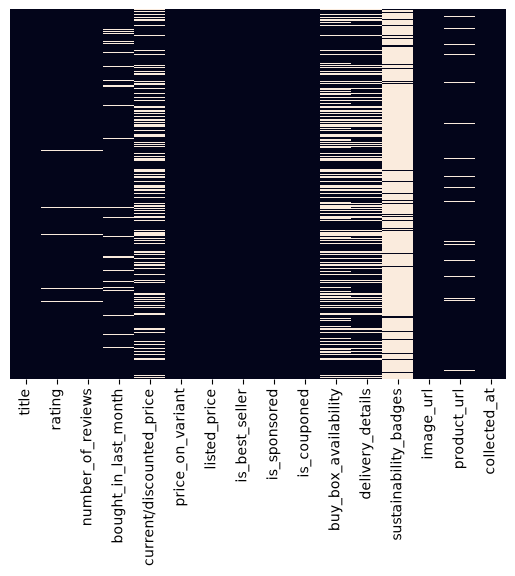

```python
sns.heatmap(df.isnull(),cbar=False,yticklabels=False)
```

## Phase 1 Exploration conclusion:

- 8 null columns
- wrong datatypes
- incorrect column values
- `price_on_variant` is the most annoying column

*more to be found!*

## phase 2 Exploration and Phase 3 Data cleaning start:

data cleaning steps:

> - 1:fix missing values
> - 2:removing duplicates **(duplicates not found)**
> - 3:correcting datatype
> - 4:cleaning objects (spaces, case issues)

To maintain accuracy of data I'll use:

> - groupby transform method
> - mask method to fill nulls
> - feature enginerring

Applied step 1 dropping rows by `product_url`

> what is the purpose for a row if the orignal source cannot exist  
> *but in if priority data visualization i would have kept!*

```python
df=df.dropna(subset=['product_url'])
```

```python
df['is_sponsored'].value_counts()
```

```
is_sponsored
Organic      35114
Sponsored     5492
Name: count, dtype: int64
```

Hmm `is_best_seller` contains percetage values

```python
df['is_best_seller'].value_counts()
```

```
is_best_seller
No Badge             39048
Amazon's               635
Best Seller            271
Limited time deal      219
Save 30%               125
Ends in                 97
Save 10%                61
Save 18%                57
Save 17%                51
Save 12%                26
Save 9%                 14
Save 77%                 2
Name: count, dtype: int64
```

*Nothing to sniff here*

```python
df['sustainability_badges'].value_counts()
```

```
sustainability_badges
Small Business                    1326
Carbon impact                      769
Works with Alexa                   425
Energy efficiency                  262
Alexa Built-in                     184
Manufacturing practices            148
Energy efficiency +3 more          121
Energy efficiency +1 more           93
Forestry practices                  18
Safer chemicals +2 more             18
Recycled materials +2 more           7
Recycled materials                   6
Safer chemicals +1 more              5
Recycled materials +3 more           4
Made in Italy                        4
1 sustainability certification       1
Name: count, dtype: int64
```

```python
df['collected_at'].value_counts()
```

```
collected_at
2025-08-21 11:16:09    33
2025-08-27 07:41:44    33
2025-08-27 07:42:22    33
2025-08-27 07:50:25    33
2025-08-27 07:51:04    33
                       ..
2025-08-30 19:30:40     2
2025-08-24 22:26:13     1
2025-08-27 07:39:48     1
2025-08-27 08:04:15     1
2025-08-30 00:42:32     1
Name: count, Length: 1556, dtype: int64
```

column `collected_at` does not contain any *null values* so converting it to *DatedandTime* format

```python
df['collected_at']=pd.to_datetime(df['collected_at'])
```

```python
df['is_couponed'].value_counts().head(10)
```

```
is_couponed
No Coupon                    38659
Save $16.00  with coupon       438
Save 15%  with coupon          398
Save 10%  with coupon          218
Save 5%  with coupon           191
Save 50%  with coupon          123
Save $11.00  with coupon       120
Save $100.00  with coupon       97
Save 40%  with coupon           96
Save $25.00  with coupon        65
Name: count, dtype: int64
```

Hmmm `is_couponed` contains both percentage and amount

```python
df['listed_price'].value_counts()
```

```
listed_price
No Discount    29110
$79.99           500
$29.99           405
$43.99           241
$23.99           232
               ...
$226.51            1
$4,995.95          1
$16.97             1
$2,999.99          1
$950.43            1
Name: count, Length: 882, dtype: int64
```

applied step 4:  
`listed_price` only contains amount but to actually use it I must strip down text and signs

```python
df['listed_price']=df['listed_price'].replace('No Discount',np.nan).str.strip()
```

```python
df['listed_price']=df['listed_price'].str.replace(r'\$|,','',regex=True)
```

```python
df['listed_price']=df['listed_price'].astype(float)
```

If a badge dosen't exist from `sustainability_badges` then replace it with *Unknown*

```python
df['sustainability_badges']=df['sustainability_badges'].fillna('Unknown')
```

Applied step 4:  
cleaning `rating` column

```python
df['rating']=df['rating'].str.replace(' out of 5 stars','',regex=True)
```

```python
df['rating']=df['rating'].astype(float)
```

Detecting outliers using simple `.describe()`

- *No outlier found!*

```python
df['rating'].describe()
```

```
count    39584.000000
mean         4.381783
std          0.388122
min          1.000000
25%          4.200000
50%          4.500000
75%          4.600000
max          5.000000
Name: rating, dtype: float64
```

Implacing **mean** of `rating` by group of `is_sponsored & sustainability_badges`

```python
rating_cleaned=df.groupby(['is_sponsored','sustainability_badges'])['rating'].transform(lambda x: round(x.mean(),1))
df['rating']=df['rating'].fillna(rating_cleaned)
```

Cleaning `number_of_reviews`

```python
df['number_of_reviews']=df['number_of_reviews'].str.replace(',','',regex=True)
```

```python
df['number_of_reviews']=df['number_of_reviews'].astype(float)
```

Finding best method to impute **nulls** form `number_of_reviews`

```python
print(df['number_of_reviews'].value_counts())
print(f"Mean: {df['number_of_reviews'].mean()}")
print(f"Median: {df['number_of_reviews'].median()}")
```

```
number_of_reviews
25.0        626
1.0         524
8.0         478
30.0        409
17.0        409
           ...
33388.0       1
4874.0        1
119218.0      1
137630.0      1
1589.0        1
Name: count, Length: 4269, dtype: int64
Mean: 2891.6046887631364
Median: 336.0
```

```python
df.groupby(['rating','is_sponsored'])['number_of_reviews'].transform(lambda x: np.round(x.median(),1))
```

```
0         182.0
1         132.0
2         182.0
3         659.0
4        1895.0
          ...
42670       4.0
42671     508.0
42672     335.0
42673    1460.0
42674     227.0
Name: number_of_reviews, Length: 40606, dtype: float64
```

**mode** is skewing values instead using groupby **median** of `rating` & `is_sponsored` to fill **nulls**

```python
review_cleaning=df.groupby(['rating','is_sponsored'])['number_of_reviews'].transform(lambda x: np.round(x.median(),1))
df['number_of_reviews']=df['number_of_reviews'].fillna(review_cleaning)
```

```python
df['number_of_reviews']=df['number_of_reviews'].astype(int)
```

column `bought_in_last_month` is special because the number of buyers are corelated with reviews

- first step is to clean `bought_in_last_month` to float
- applying groupby `number_of_reviews` to implace nulls by **median** of `bought_in_last_month`

```python
df['bought_in_last_month']=df['bought_in_last_month'].str.extract(r'(^\d+K?)')
```

```python
def fixer (value):
    if 'K' in str(value):
        return float(value.replace('K',''))*1000
    else:
        return float(value)
```

```python
df['bought_in_last_month']=df['bought_in_last_month'].apply(fixer)
```

```python
df['bought_in_last_month']=df['bought_in_last_month'].astype('float')
```

applying `.median()` groupby

> why `.median()` because `.mean()` would skew accuracy due to big range of reviews

```python
filled=df.groupby('number_of_reviews')['bought_in_last_month'].transform(lambda x: x.median())
```

```python
df['bought_in_last_month']=df['bought_in_last_month'].fillna(filled)
```

```python
nullg=df[df['bought_in_last_month'].isna()].groupby('number_of_reviews').size()
print(nullg)
```

```
number_of_reviews
242       2
334       1
337       3
438       1
464       1
         ..
55203     1
57813     1
73561     1
81098     1
138711    1
Length: 205, dtype: int64
```

aggregating all groups to find which groups have 0 count

```python
gs=df.groupby('number_of_reviews')['bought_in_last_month'].agg(['count','size'])
ang=gs[gs['count']==0]
print(ang)
```

```
                   count  size
number_of_reviews
242                    0     2
334                    0     1
337                    0     3
438                    0     1
464                    0     1
...                  ...   ...
55203                  0     1
57813                  0     1
73561                  0     1
81098                  0     1
138711                 0     1

[205 rows x 2 columns]
```

Still some **nulls** where found because some groups where empty so im implacing **nulls** by **median** of `bought_in_last_month`

```python
df['bought_in_last_month']=df['bought_in_last_month'].fillna(df['bought_in_last_month'].median())
```

Analayzing `price_on_variant` and it contains percentage and amounts values

```python
df['price_on_variant'].value_counts()
```

```
price_on_variant
basic variant price: nan                           20144
basic variant price: $9.99                           324
basic variant price: $119.95                         298
basic variant price: $169.99                         264
basic variant price: $29.99                          217
                                                   ...
basic variant price: 50% off coupon applied            1
basic variant price: $118.95                           1
basic variant price: $120.00 off coupon applied        1
basic variant price: $90.00 off coupon applied         1
basic variant price: $30.00 off coupon applied         1
Name: count, Length: 3400, dtype: int64
```

`is_couponed` contains both percentage and amount values

```python
df['is_couponed'].value_counts().head(10)
```

```
is_couponed
No Coupon                    38659
Save $16.00  with coupon       438
Save 15%  with coupon          398
Save 10%  with coupon          218
Save 5%  with coupon           191
Save 50%  with coupon          123
Save $11.00  with coupon       120
Save $100.00  with coupon       97
Save 40%  with coupon           96
Save $25.00  with coupon        65
Name: count, dtype: int64
```

```python
df['is_best_seller'].value_counts()
```

```
is_best_seller
No Badge             39048
Amazon's               635
Best Seller            271
Limited time deal      219
Save 30%               125
Ends in                 97
Save 10%                61
Save 18%                57
Save 17%                51
Save 12%                26
Save 9%                 14
Save 77%                 2
Name: count, dtype: int64
```

Time for real-work — Feature Engineering

- extracting percentages and amounts and putting them into respective columns to be later used for processing
- columns: `cp%`, `cp$`, `bg%`

```python
df['cp%']=df['is_couponed'].str.extract(r'Save (\d+)%').astype(float)/100
```

```python
df['cp$']=df['is_couponed'].str.extract(r'Save \$(\d+).\d+').astype(float)
```

```python
df['bg%']=df['is_best_seller'].str.extract(r'Save (\d+)%').astype(float)/100
```

last step of fix for `current/discounted_price`

```python
df['current/discounted_price']=df['current/discounted_price'].str.replace(',','',regex=False)
df['current/discounted_price']=df['current/discounted_price'].astype(float)
```

### creation for bool series (**masks**) for `cp%`, `cp$` and `bg%`

> for `cp%`
> - where `current/discounted_price` **null** but `cp%` **not null**
> - where `of listed_price` **null** but `cp%` **notnull**

> for `cp$`
> - where `current/discounted_price` **null** but `cp$` & `listed_price` **not null**
> - where `listed_price` **null** but `cp$` & `current/discounted_price` **not null**

> for `bg%`
> - where `listed_price` **null** but `cp$` & `current/discounted_price` **not null**
> - where `current/discounted_price` **null** but `cp$` & `listed_price` **not null**

```python
current_nulls_n_couponed=(df['current/discounted_price'].isna()) & (df['cp%'].notna())
df[current_nulls_n_couponed]
```

|  | title | rating | number_of_reviews | bought_in_last_month | current/discounted_price | price_on_variant | listed_price | is_best_seller | is_sponsored | is_couponed | buy_box_availability | delivery_details | sustainability_badges | image_url | product_url | collected_at | cp% | cp$ | bg% |
| --- | --- | --- | --- | --- | --- | --- | --- | --- | --- | --- | --- | --- | --- | --- | --- | --- | --- | --- | --- |

```python
listed_nulls_n_couponed=(df['listed_price'].isna()) & (df['cp%'].notna()) & (df['current/discounted_price'].notna())
df[listed_nulls_n_couponed].head()
```

|  | title | rating | number_of_reviews | bought_in_last_month | current/discounted_price | price_on_variant | listed_price | is_best_seller | is_sponsored | is_couponed | buy_box_availability | delivery_details | sustainability_badges | image_url | product_url | collected_at | cp% | cp$ | bg% |
| --- | --- | --- | --- | --- | --- | --- | --- | --- | --- | --- | --- | --- | --- | --- | --- | --- | --- | --- | --- |
| 8 | Complete Protect: One plan covers all eligible... | 4.0 | 4380 | 100.0 | 16.99 | basic variant price: nan | NaN | No Badge | Organic | Save 50% with coupon | NaN | NaN | Unknown | https://m.media-amazon.com/images/I/71tZ0n2xP9... | /Asurion-Complete-Protect/dp/B07RZ3LSHM/ref=sr... | 2025-08-21 11:14:29 | 0.50 | NaN | NaN |
| 129 | DEWALT Heavy Duty Black Edition 2-in-1 Neckban... | 4.4 | 1408 | 500.0 | 99.99 | basic variant price: nan | NaN | No Badge | Sponsored | Save 10% with coupon | Add to cart | Delivery Mon, Sep 1 | Unknown | https://m.media-amazon.com/images/I/81qzHLoSh8... | /sspa/click?ie=UTF8&spc=MToxNzQ1NzQ0NzE1NTUwMT... | 2025-08-21 11:15:31 | 0.10 | NaN | NaN |
| 319 | Belkin MagSafe-Compatible Charger, 3-in-1 Wire... | 4.4 | 3520 | 1000.0 | 119.99 | basic variant price: nan | NaN | No Badge | Sponsored | Save 15% with coupon | Add to cart | Delivery Mon, Sep 1 | Unknown | https://m.media-amazon.com/images/I/61XBmb46FV... | /sspa/click?ie=UTF8&spc=MTo2NjI0MTEwODE1NzMyOD... | 2025-08-21 11:17:40 | 0.15 | NaN | NaN |
| 383 | Belkin MagSafe-Compatible Charger, 3-in-1 Wire... | 4.4 | 3520 | 1000.0 | 119.99 | basic variant price: nan | NaN | No Badge | Sponsored | Save 15% with coupon | Add to cart | Delivery Mon, Sep 1 | Unknown | https://m.media-amazon.com/images/I/61XBmb46FV... | /sspa/click?ie=UTF8&spc=MToxNjg3MzI5MTc4NjUwMT... | 2025-08-21 11:17:53 | 0.15 | NaN | NaN |
| 546 | Belkin MagSafe-Compatible Charger, 3-in-1 Wire... | 4.4 | 3520 | 1000.0 | 119.99 | basic variant price: nan | NaN | No Badge | Sponsored | Save 15% with coupon | Add to cart | Delivery Mon, Sep 1 | Unknown | https://m.media-amazon.com/images/I/61XBmb46FV... | /sspa/click?ie=UTF8&spc=MToyMjAzOTU3MDY1MTQ5Nz... | 2025-08-21 11:19:08 | 0.15 | NaN | NaN |

```python
current_nulls_n_couponed_dollors=(df['cp$'].notna()) & (df['listed_price'].notna()) &(df['current/discounted_price'].isna())
df[current_nulls_n_couponed_dollors]
```

|  | title | rating | number_of_reviews | bought_in_last_month | current/discounted_price | price_on_variant | listed_price | is_best_seller | is_sponsored | is_couponed | buy_box_availability | delivery_details | sustainability_badges | image_url | product_url | collected_at | cp% | cp$ | bg% |
| --- | --- | --- | --- | --- | --- | --- | --- | --- | --- | --- | --- | --- | --- | --- | --- | --- | --- | --- | --- |

```python
listedp_nulls_n_couponed_dollors=(df['cp$'].notna()) & (df['listed_price'].isna()) & (df['current/discounted_price'].notna())
df[listedp_nulls_n_couponed_dollors].head()
```

|  | title | rating | number_of_reviews | bought_in_last_month | current/discounted_price | price_on_variant | listed_price | is_best_seller | is_sponsored | is_couponed | buy_box_availability | delivery_details | sustainability_badges | image_url | product_url | collected_at | cp% | cp$ | bg% |
| --- | --- | --- | --- | --- | --- | --- | --- | --- | --- | --- | --- | --- | --- | --- | --- | --- | --- | --- | --- |
| 57 | KODAK 10.1 Inch WiFi Digital Picture Frame,128... | 4.1 | 264 | 100.0 | 85.99 | basic variant price: nan | NaN | No Badge | Sponsored | Save $16.00 with coupon | Add to cart | Delivery Mon, Sep 1 | Unknown | https://m.media-amazon.com/images/I/716bPrNJ0G... | /sspa/click?ie=UTF8&spc=MTo0NDAxNDYzMjM5NDUwMT... | 2025-08-21 11:15:00 | NaN | 16.0 | NaN |
| 115 | KODAK 10.1 Inch WiFi Digital Picture Frame,128... | 4.1 | 264 | 100.0 | 85.99 | basic variant price: nan | NaN | No Badge | Sponsored | Save $16.00 with coupon | Add to cart | Delivery Mon, Sep 1 | Unknown | https://m.media-amazon.com/images/I/716bPrNJ0G... | /sspa/click?ie=UTF8&spc=MToxNzQ1NzQ0NzE1NTUwMT... | 2025-08-21 11:15:31 | NaN | 16.0 | NaN |
| 172 | acer 311 Chromebook 2025 Flagship Slim Light L... | 4.2 | 69 | 50.0 | 229.00 | basic variant price: nan | NaN | No Badge | Sponsored | Save $20.00 with coupon | Add to cart | Delivery Mon, Sep 1 | Unknown | https://m.media-amazon.com/images/I/71fpzX1OKu... | /sspa/click?ie=UTF8&spc=MTo0MTMyNTA1NDQ0MTYwMz... | 2025-08-21 11:15:58 | NaN | 20.0 | NaN |
| 173 | KODAK 10.1 Inch WiFi Digital Picture Frame,128... | 4.1 | 264 | 100.0 | 85.99 | basic variant price: nan | NaN | No Badge | Sponsored | Save $16.00 with coupon | Add to cart | Delivery Mon, Sep 1 | Unknown | https://m.media-amazon.com/images/I/716bPrNJ0G... | /sspa/click?ie=UTF8&spc=MTo0MTMyNTA1NDQ0MTYwMz... | 2025-08-21 11:15:58 | NaN | 16.0 | NaN |
| 204 | KODAK 10.1 Inch WiFi Digital Picture Frame,128... | 4.1 | 264 | 100.0 | 85.99 | basic variant price: nan | NaN | No Badge | Sponsored | Save $16.00 with coupon | Add to cart | Delivery Mon, Sep 1 | Unknown | https://m.media-amazon.com/images/I/716bPrNJ0G... | /sspa/click?ie=UTF8&spc=MTo0ODUyMDkxNDk4NDQ5OT... | 2025-08-21 11:16:09 | NaN | 16.0 | NaN |

```python
listed_nulls_n_bg=(df['bg%'].notna()) & (df['current/discounted_price'].notna()) & (df['listed_price'].isna())
listed_nulls_n_bg.value_counts()
```

```
False    40606
Name: count, dtype: int64
```

```python
current_nulls_n_bg=(df['bg%'].notna()) & (df['current/discounted_price'].isna()) & (df['listed_price'].notna())
current_nulls_n_bg.value_counts()
```

```
False    40606
Name: count, dtype: int64
```

### Application of Masks time

> *usable masks list*
> - for `cp%` : `listed_price` **null** but `cp$` & `current/discounted_price` **notnull**
> - for `cp$` `listed_price` **null** but `cp$` & `current/discounted_price` **notnull**
> - **mask found no usable rows for** `bg%`

application of mask where filling `listed_price` by reversing percentage formula to calculate orignal price by divison of `current/discounted_price` / `1-cp%`

```python
df.loc[listed_nulls_n_couponed,'listed_price']=round(df.loc[listed_nulls_n_couponed,'current/discounted_price']/(1-df.loc[listed_nulls_n_couponed,'cp%']),2)
```

Just implaced `current/discounted_price` + `cp$` where mask was true for `listed_price`  
**meaning:** *I just sum current price with coupon amount and filled where it should belong*

```python
df.loc[listedp_nulls_n_couponed_dollors,'listed_price']=(df.loc[listedp_nulls_n_couponed_dollors,'current/discounted_price']) + (df.loc[listedp_nulls_n_couponed_dollors,'cp$'])
```

Analyzing the most notorious column `price_on_variant` where coupon % is available and current price exists

```python
df['price_on_variant'].value_counts().tail(10)
```

```
price_on_variant
basic variant price: $1,620.00                     1
basic variant price: $230.45                       1
basic variant price: $114.12                       1
basic variant price: $109.39                       1
basic variant price: $1,049.99                     1
basic variant price: 50% off coupon applied        1
basic variant price: $118.95                       1
basic variant price: $120.00 off coupon applied    1
basic variant price: $90.00 off coupon applied     1
basic variant price: $30.00 off coupon applied     1
Name: count, dtype: int64
```

cleaning `price_on_variant` with creation of masks where only price amount exists not coupon percentage by using regex pattern `price:\s\$\d+\.\d+$` telling the regex to stop on the last zero of amount

- for example **price: $12.99** <- mask stops at exactly 9

> masks for `price_on_variant` and their logic:
> - First mask is just to cross and verify if $ dosen't exist but % does and where `current/discounted_price` is **null** **<-** *empty mask all values are false hehe*😅
> - where `price_on_variant` contains amount and `current/discounted_price` is **null** **<-** *found 8852 truths; time to implace*
> - mask where `listed_price` is **null** but `current/discounted_price` **not null** **<-** *found 16042 rows where `listed_price` is missing yet those values exist in `current/discounted_price`*

```python
df['price_on_variant']=df['price_on_variant'].str.strip()
```

```python
maskre=(~df['price_on_variant'].str.contains(r'price:\s\$\d+\.\d+$')) & (df['price_on_variant'].str.contains(r'price:\s\$\d+\.\d+')) & (df['current/discounted_price'].isna())
df[maskre].head(5)
```

|  | title | rating | number_of_reviews | bought_in_last_month | current/discounted_price | price_on_variant | listed_price | is_best_seller | is_sponsored | is_couponed | buy_box_availability | delivery_details | sustainability_badges | image_url | product_url | collected_at | cp% | cp$ | bg% |
| --- | --- | --- | --- | --- | --- | --- | --- | --- | --- | --- | --- | --- | --- | --- | --- | --- | --- | --- | --- |

```python
pricever_current=(df['price_on_variant'].str.contains(r'price:\s\$\d+\.\d+$')) & (df['current/discounted_price'].isna())
pricever_current.value_counts()
```

```
False    31754
True      8852
Name: count, dtype: int64
```

Feature Engeineering  
Extracted a new column `price$` by regex group `(\d+\.\d+)`= *means only price part of values*

```python
df['price$']=df['price_on_variant'].str.extract(r'price:\s\$(\d+\.\d+)$').astype(float)
```

just filled the the nulls of `current/discounted_price` using mask where value existed in `price$`

```python
df.loc[pricever_current,'current/discounted_price']=df.loc[pricever_current,'price$'].astype(float)
```

Did the same for `listed_price` as above cell imputed nulls from `price$` where mask was true

```python
df.loc[pricever_current,'listed_price']=df.loc[pricever_current,'price$'].astype(float)
```

analaysis of relationship between `price_on_variant` and `cp%`

- found the relationship of 75 rows and found that percentage is non stacking so ignore the `price_on_variant` coupon % values

```python
df['price_on_variant'].str.extract(r'price:\s(\d+)\%\soff').notna().value_counts()
```

```
0
False    40531
True        75
Name: count, dtype: int64
```

```python
((df['cp%']) == (df['price_on_variant'].str.extract(r'price:\s(\d+)\%\soff').squeeze().astype(float)/100)).value_counts()
```

```
False    40531
True        75
Name: count, dtype: int64
```

Re-check if **null** values of `current/discounted_price` exist in `listed_price` where `cp$` or `price$` **not null**

- answer is found to be *nooo it dosen't!*

```python
((df['current/discounted_price'].isna()) & ((df['price$'].notna()) | (df['cp$'].notna())) & (df['listed_price'].notna())).value_counts()
```

```
False    40606
Name: count, dtype: int64
```

Re-check if **null** values of `current/discounted_price` exist in `listed_price`

- Answer: *noo it dosen't*

```python
((df['current/discounted_price'].isna()) & (df['listed_price'].notna())).value_counts()
```

```
False    40606
Name: count, dtype: int64
```

```python
df['current/discounted_price'].isna().value_counts()
```

```
current/discounted_price
False    37989
True      2617
Name: count, dtype: int64
```

```python
maybe_last_mask=(df['listed_price'].isna()) & (df['current/discounted_price'].notna())
```

```python
maybe_last_mask.value_counts()
```

```
False    24564
True     16042
Name: count, dtype: int64
```

```python
df['listed_price'].isna().value_counts()
```

```
listed_price
False    21947
True     18659
Name: count, dtype: int64
```

```python
df.loc[maybe_last_mask,'listed_price']=df.loc[maybe_last_mask,'current/discounted_price']
```

dropping all rows by the subset of **nulls** from `current/discounted_price`

- I'm droping because i want maximum data accuracy like needle in a haystack

```python
df=df.dropna(subset=['current/discounted_price'])
print(len(df))
```

```
37989
```

Hmm my analysis was right there was relationship of listed price with current price now buy dropping by subset of **nulls** from `current/discounted_price` the `listed_price` which had **nulls** before they where also dropped, If i had imputed nulls by common methods like `.mean()` or `.median()` the accuracy would have got skewed 😎

```python
df['listed_price'].isnull().value_counts()
```

```
listed_price
False    37989
Name: count, dtype: int64
```

last two column remains

```python
df['buy_box_availability'].value_counts()
```

```
buy_box_availability
Add to cart    26091
Name: count, dtype: int64
```

By analyzing heatmap i saw a pattern where line crossed the bounds of `buy_box_availability` to `delivery_details` that only means if **null** of `buy_box_availability` is "out of stock" then the same **null** in `delivery_details` must share a relation of

- if a item has no data of avalibility then it must be out of stock and if a item has no data of deliivery type it must be because the product is already out of stock

using this sense i created a mask for checking and i found out that there was a co-relation of **nulls** between `buy_box_availability` and `delivery_details`

```python
hopefully_last_mask=(df['buy_box_availability'].isna()) & (df['delivery_details'].isna())
hopefully_last_mask.value_counts()
```

```
False    29084
True      8905
Name: count, dtype: int64
```

filled **nulls** of `buy_box_availability` "with out of stock" flag

```python
df['buy_box_availability']=df['buy_box_availability'].fillna('Out of stock')
```

by applying the co-relation of both columns i filled `delivery_details` with "Out of stock" flag where `buy_box_availability` is also "Out of stock"

```python
df.loc[hopefully_last_mask,'delivery_details']='Out of stock'
```

all other **nulls** must be Unknown

```python
df['delivery_details']=df['delivery_details'].fillna('Unknown')
```

```python
df['delivery_details'].value_counts()
```

```
delivery_details
Out of stock                                                        8905
Delivery Mon, Sep 1                                                 5629
Delivery Thu, Sep 4                                                 4008
Delivery Thu, Sep 11                                                3549
Delivery Tue, Sep 2                                                 2929
                                                                    ...
FREE delivery Sep 4 - 10Or fastest delivery Sep 4 - 7                  1
FREE delivery Sep 5 - 10Or fastest delivery Thu, Sep 4                 1
FREE delivery Fri, Sep 5Or fastest delivery Tue, Sep 2                 1
FREE delivery Sep 5 - 10Or fastest delivery Sep 4 - 6                  1
FREE delivery Sep 23 - Oct 18Or fastest delivery Sep 23 - Oct 13       1
Name: count, Length: 298, dtype: int64
```

last step before data Exploration dorpping all columns which i created for masks/imputation and an annoying column `price_on_variant` which won't be used anyways since data is clean

```python
df=df.drop(columns=['price_on_variant','cp%','cp$','bg%','price$'])
```

## phase 3 Data Verification and saving of dataset to *`csv`*

```python
df.head(10)
```

|  | title | rating | number_of_reviews | bought_in_last_month | current/discounted_price | listed_price | is_best_seller | is_sponsored | is_couponed | buy_box_availability | delivery_details | sustainability_badges | image_url | product_url | collected_at |
| --- | --- | --- | --- | --- | --- | --- | --- | --- | --- | --- | --- | --- | --- | --- | --- |
| 0 | BOYA BOYALINK 2 Wireless Lavalier Microphone f... | 4.6 | 375 | 300.0 | 89.68 | 159.00 | No Badge | Sponsored | Save 15% with coupon | Add to cart | Delivery Mon, Sep 1 | Carbon impact | https://m.media-amazon.com/images/I/71pAqiVEs3... | /sspa/click?ie=UTF8&spc=MTo4NzEzNDY2NTQ5NDYxND... | 2025-08-21 11:14:29 |
| 1 | LISEN USB C to Lightning Cable, 240W 4 in 1 Ch... | 4.3 | 2457 | 6000.0 | 9.99 | 15.99 | No Badge | Sponsored | No Coupon | Add to cart | Delivery Fri, Aug 29 | Unknown | https://m.media-amazon.com/images/I/61nbF6aVIP... | /sspa/click?ie=UTF8&spc=MTo4NzEzNDY2NTQ5NDYxND... | 2025-08-21 11:14:29 |
| 2 | DJI Mic 2 (2 TX + 1 RX + Charging Case), Wirel... | 4.6 | 3044 | 2000.0 | 314.00 | 349.00 | No Badge | Sponsored | No Coupon | Add to cart | Delivery Mon, Sep 1 | Unknown | https://m.media-amazon.com/images/I/61h78MEXoj... | /sspa/click?ie=UTF8&spc=MTo4NzEzNDY2NTQ5NDYxND... | 2025-08-21 11:14:29 |
| 3 | Apple AirPods Pro 2 Wireless Earbuds, Active N... | 4.6 | 35882 | 10000.0 | 162.24 | 162.24 | Best Seller | Organic | No Coupon | Out of stock | Out of stock | Unknown | https://m.media-amazon.com/images/I/61SUj2aKoE... | /Apple-Cancellation-Transparency-Personalized-... | 2025-08-21 11:14:29 |
| 4 | Apple AirTag 4 Pack. Keep Track of and find Yo... | 4.8 | 28988 | 10000.0 | 72.74 | 72.74 | No Badge | Organic | No Coupon | Out of stock | Out of stock | Unknown | https://m.media-amazon.com/images/I/61bMNCeAUA... | /Apple-MX542LL-A-AirTag-Pack/dp/B0D54JZTHY/ref... | 2025-08-21 11:14:29 |
| 5 | Texas Instruments TI-84 Plus CE Color Graphing... | 4.6 | 44522 | 100000.0 | 99.95 | 99.95 | Best Seller | Organic | No Coupon | Out of stock | Out of stock | Unknown | https://m.media-amazon.com/images/I/71AyPChhFd... | /Texas-Instruments-TI-84-Graphing-Calculator/d... | 2025-08-21 11:14:29 |
| 6 | Apple AirPods 4 Wireless Earbuds, Bluetooth He... | 4.5 | 13466 | 10000.0 | 88.11 | 88.11 | No Badge | Organic | No Coupon | Out of stock | Out of stock | Unknown | https://m.media-amazon.com/images/I/61iBtxCUab... | /Apple-Bluetooth-Headphones-Personalized-Effor... | 2025-08-21 11:14:29 |
| 7 | Apple AirTag. Keep Track of and find Your Keys... | 4.6 | 38105 | 10000.0 | 23.04 | 23.04 | Best Seller | Organic | No Coupon | Out of stock | Out of stock | Unknown | https://m.media-amazon.com/images/I/71rP7f78eF... | /Apple-MX532LL-A-AirTag/dp/B0CWXNS552/ref=sr_1... | 2025-08-21 11:14:29 |
| 8 | Complete Protect: One plan covers all eligible... | 4.0 | 4380 | 100.0 | 16.99 | 33.98 | No Badge | Organic | Save 50% with coupon | Out of stock | Out of stock | Unknown | https://m.media-amazon.com/images/I/71tZ0n2xP9... | /Asurion-Complete-Protect/dp/B07RZ3LSHM/ref=sr... | 2025-08-21 11:14:29 |
| 9 | Apple iPad 11-inch: A16 chip, 11-inch Model, L... | 4.7 | 7308 | 10000.0 | 284.05 | 284.05 | Best Seller | Organic | No Coupon | Out of stock | Out of stock | Energy efficiency | https://m.media-amazon.com/images/I/61aPY8odPS... | /Apple-iPad-11-inch-Display-All-Day/dp/B0DZ75T... | 2025-08-21 11:14:29 |

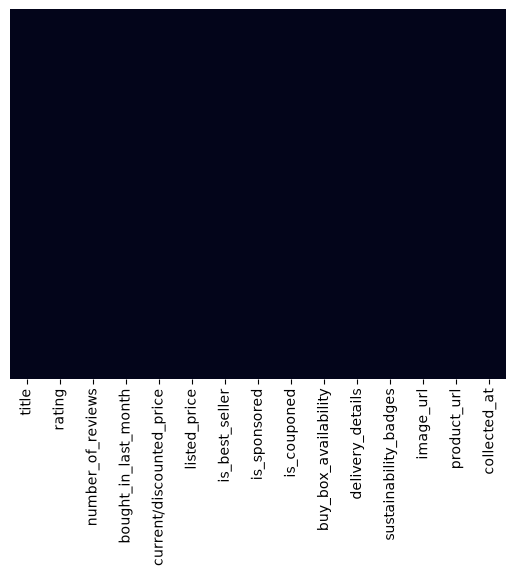

```python
sns.heatmap(df.isna(),cbar=False,yticklabels=False)
```

```python
df.isna().sum()
```

```
title                       0
rating                      0
number_of_reviews           0
bought_in_last_month        0
current/discounted_price    0
listed_price                0
is_best_seller              0
is_sponsored                0
is_couponed                 0
buy_box_availability        0
delivery_details            0
sustainability_badges       0
image_url                   0
product_url                 0
collected_at                0
dtype: int64
```

```python
df.info()
```

```
<class 'pandas.DataFrame'>
Index: 37989 entries, 0 to 42674
Data columns (total 15 columns):
 #   Column                    Non-Null Count  Dtype
---  ------                    --------------  -----
 0   title                     37989 non-null  str
 1   rating                    37989 non-null  float64
 2   number_of_reviews         37989 non-null  int64
 3   bought_in_last_month      37989 non-null  float64
 4   current/discounted_price  37989 non-null  float64
 5   listed_price              37989 non-null  float64
 6   is_best_seller            37989 non-null  str
 7   is_sponsored              37989 non-null  str
 8   is_couponed               37989 non-null  str
 9   buy_box_availability      37989 non-null  str
 10  delivery_details          37989 non-null  str
 11  sustainability_badges     37989 non-null  str
 12  image_url                 37989 non-null  str
 13  product_url               37989 non-null  str
 14  collected_at              37989 non-null  datetime64[us]
dtypes: datetime64[us](1), float64(4), int64(1), str(9)
memory usage: 4.6 MB
```

*i like my column to be defaulted to orignal format just so it feels right*

- **remove these two cells below if you are doing data visualization**

```python
def unfixer(value):
    if value >= 1000:
        return str(int(value / 1000)) + "K+ bought in past month"
    else:
        return str(int(value)) + "+ bought in past month"
```

```python
df['bought_in_last_month']=df['bought_in_last_month'].apply(unfixer)
```

**Data to CSV 😀**

```python
df.to_csv('amazon_products_sales_data_cleaned.csv',index=False)
```